# Homework 6

Hannah Shafer

2/23/2022

1. Running the sample code

Open libraries

```r
library(ggplot2) # for graphics
library(MASS) # for maximum likelihood estimation
```

Read in data vector and generate fake data

```r
# quick and dirty, a truncated normal distribution to work on the solution set

z <- rnorm(n=3000,mean=0.2)
z <- data.frame(1:3000,z)
names(z) <- list("ID","myVar")
z <- z[z$myVar>0,]
str(z)
```

```
## 'data.frame':    1737 obs. of  2 variables:
##  $ ID   : int  1 3 4 5 7 9 12 13 19 20 ...
##  $ myVar: num  0.828 0.726 0.65 0.176 0.219 ...
```

```r
# data.frame':  1725 obs. of  2 variables:
#  $ ID   : int  8 10 11 13 16 17 19 22 24 29 ...
#  $ myVar: num  0.276 0.878 1.04 0.431 2.484
summary(z$myVar)
```

```
##     Min.  1st Qu.   Median     Mean  3rd Qu.     Max.
## 0.000781 0.337917 0.726945 0.848326 1.215819 3.754458
```

```r
#     Min.  1st Qu.   Median     Mean  3rd Qu.
# 0.000904 0.348635 0.760045 0.877109 1.270632
#     Max.
# 4.085390
```

Plot a histogram of the data

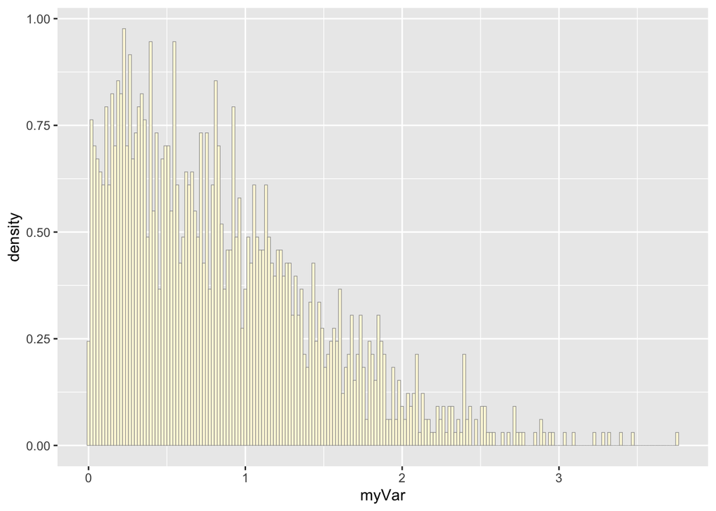

```r
p1 <- ggplot(data=z, aes(x=myVar, y=..density..)) +
  geom_histogram(color="grey60",fill="cornsilk",size=0.2, bins=200)
print(p1) # prints out histogram
```

Add an empirical density curve

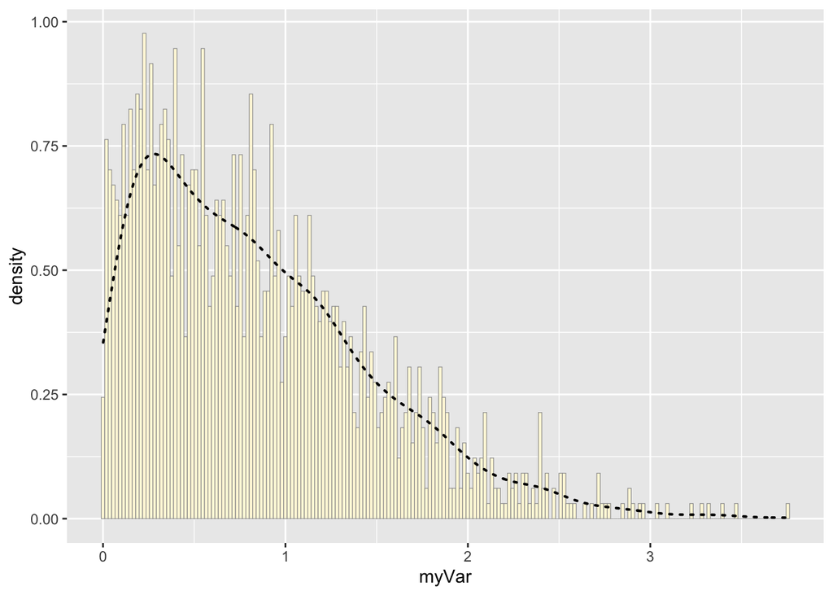

```r
p1 <-  p1 +  geom_density(linetype="dotted",size=0.75)
print(p1) # prints histogram from before but with a dotted density curve
```

Get maximum likelihood parameters for `normal`

```r
normPars <- fitdistr(z$myVar,"normal") # fit normal distribution to the data
print(normPars)
```

```
##       mean          sd
##   0.84832570   0.63270331
##  (0.01518099) (0.01073458)
```

```r
 #      mean          sd
 #  0.87710945   0.63904730
 # (0.01538645) (0.01087986)
str(normPars)
```

```
## List of 5
##  $ estimate: Named num [1:2] 0.848 0.633
##   ..- attr(*, "names")= chr [1:2] "mean" "sd"
##  $ sd      : Named num [1:2] 0.0152 0.0107
##   ..- attr(*, "names")= chr [1:2] "mean" "sd"
##  $ vcov    : num [1:2, 1:2] 0.00023 0 0 0.000115
##   ..- attr(*, "dimnames")=List of 2
##   .. ..$ : chr [1:2] "mean" "sd"
##   .. ..$ : chr [1:2] "mean" "sd"
##  $ n       : int 1737
##  $ loglik  : num -1670
##  - attr(*, "class")= chr "fitdistr"
```

```r
# List of 5
#  $ estimate: Named num [1:2] 0.877 0.639
#   ..- attr(*, "names")= chr [1:2] "mean" "sd"
#  $ sd      : Named num [1:2] 0.0154 0.0109
#   ..- attr(*, "names")= chr [1:2] "mean" "sd"
#  $ vcov    : num [1:2, 1:2] 0.000237 0 0 0.000118
#   ..- attr(*, "dimnames")=List of 2
#   .. ..$ : chr [1:2] "mean" "sd"
#   .. ..$ : chr [1:2] "mean" "sd"
#  $ n       : int 1725
#  $ loglik  : num -1675
#  - attr(*, "class")= chr "fitdistr"
normPars$estimate["mean"] # note structure of getting a named attribute
```

```
##      mean
## 0.8483257
```

```r
#      mean
# 0.8771095
```

Plot the `normal` probability density; involves calling the `dnorm` function inside ggplot’s `stat_function` `stat_function` in help system- “draws a function as a continuous curve” - this would allow us to add a smooth function to any ggplot

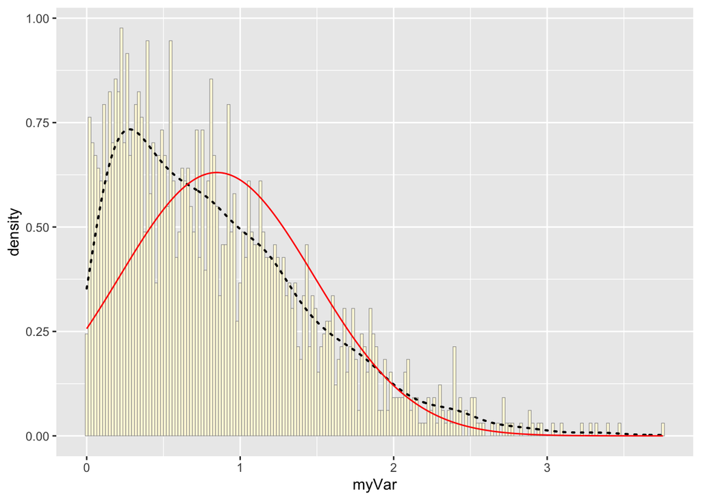

```r
meanML <- normPars$estimate["mean"]
sdML <- normPars$estimate["sd"]

xval <- seq(0,max(z$myVar),len=length(z$myVar))

stat <- stat_function(aes(x = xval, y = ..y..), fun = dnorm, colour="red", n = length(z$myVar), args = list(mean = meanML, sd = sdML))

p1 + stat # prints the histogram with empirical density curve from before, but adds the normal density curve (note biased mean)
```

Plot `exponential` probability density

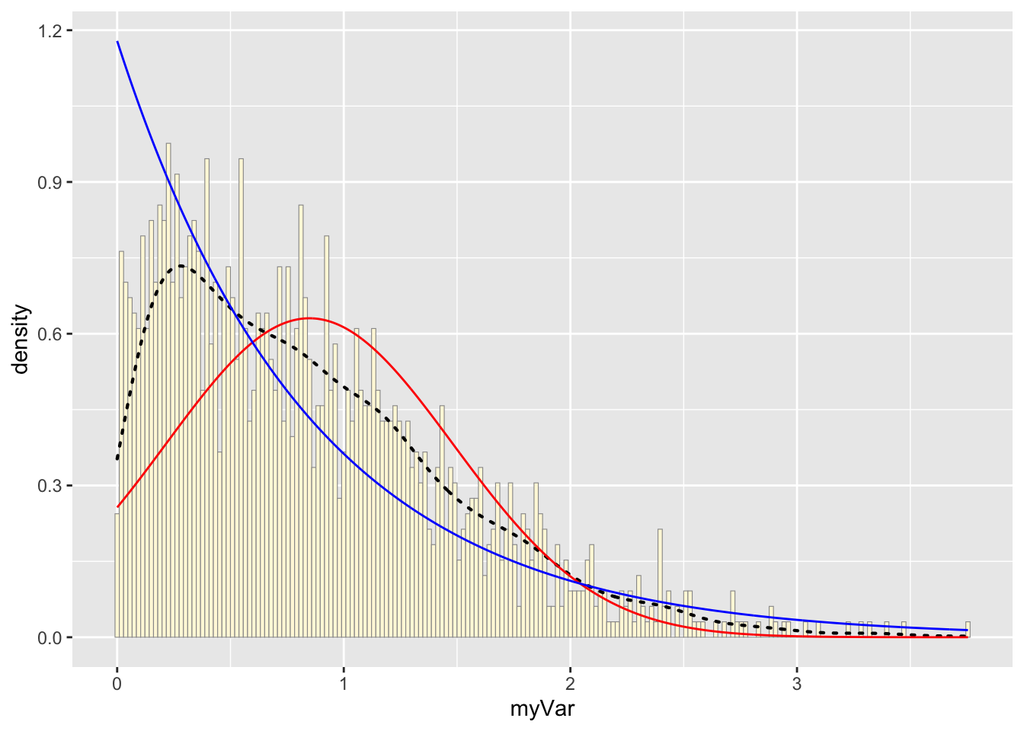

```r
expoPars <- fitdistr(z$myVar,"exponential")
rateML <- expoPars$estimate["rate"]

stat2 <- stat_function(aes(x = xval, y = ..y..), fun = dexp, colour="blue", n = length(z$myVar), args = list(rate=rateML))

p1 + stat + stat2 # exponential curve added to plot
```

Plot `uniform` probability density

```r
stat3 <- stat_function(aes(x = xval, y = ..y..), fun = dunif, colour="darkgreen", n = length(z$myVar), args = list(min=min(z$myVar), max=max(z$myVar)))
 p1 + stat + stat2 + stat3
```

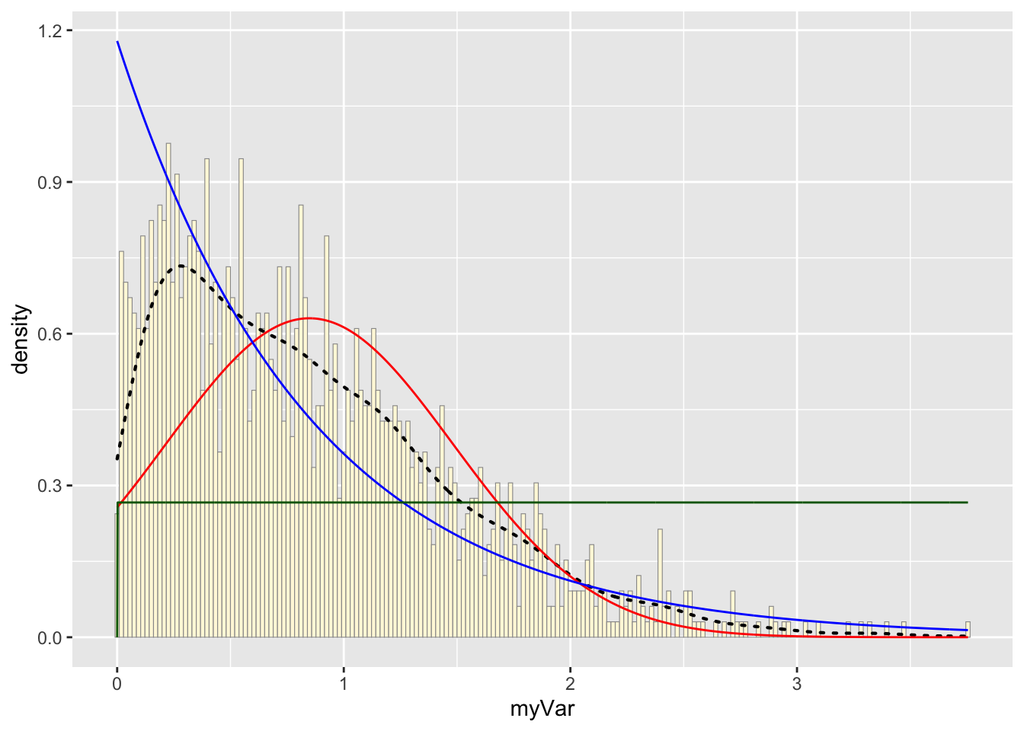

Plot `gamma` probability density

```r
gammaPars <- fitdistr(z$myVar,"gamma")
shapeML <- gammaPars$estimate["shape"]
rateML <- gammaPars$estimate["rate"]

stat4 <- stat_function(aes(x = xval, y = ..y..), fun = dgamma, colour="brown", n = length(z$myVar), args = list(shape=shapeML, rate=rateML))
 p1 + stat + stat2 + stat3 + stat4
```

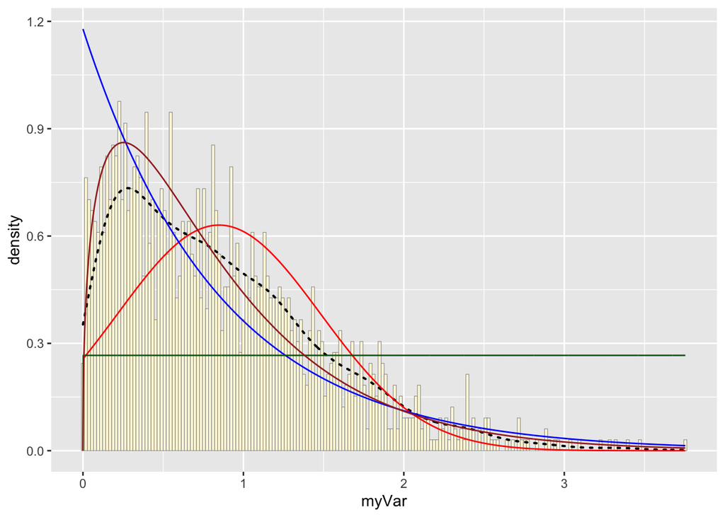

Plot `beta` probability density

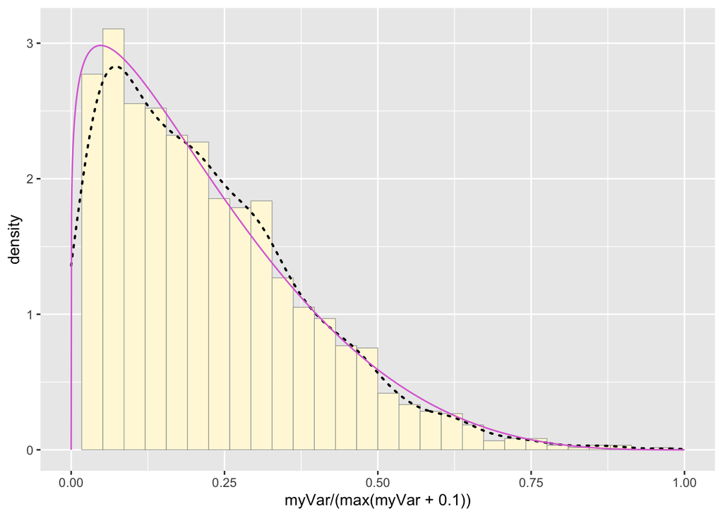

```r
pSpecial <- ggplot(data=z, aes(x=myVar/(max(myVar + 0.1)), y=..density..)) +
  geom_histogram(color="grey60",fill="cornsilk",size=0.2) +
  xlim(c(0,1)) +
  geom_density(size=0.75,linetype="dotted")

betaPars <- fitdistr(x=z$myVar/max(z$myVar + 0.1),start=list(shape1=1,shape2=2),"beta")
shape1ML <- betaPars$estimate["shape1"]
shape2ML <- betaPars$estimate["shape2"]

statSpecial <- stat_function(aes(x = xval, y = ..y..), fun = dbeta, colour="orchid", n = length(z$myVar), args = list(shape1=shape1ML,shape2=shape2ML))
pSpecial + statSpecial
```

2. Import data and run the analysis above on it; data imported and truncated from: https://datadryad.org/stash/dataset/doi:10.5061%2Fdryad.vdncjsxrx

```r
z <- read.table("../Bio381/MyDataFile.csv",header=TRUE,sep=",")
names(z) <- list("ID","pop", "myVar")
z <- z[z$myVar>0,]
str(z)
```

```
## 'data.frame':    1550 obs. of  3 variables:
##  $ ID   : chr  "ALB-M011A01" "ALB-M011A02" "ALB-M011A03" "ALB-M011A04" ...
##  $ pop  : chr  "ALB" "ALB" "ALB" "ALB" ...
##  $ myVar: int  101 102 108 113 100 100 102 102 114 100 ...
```

```r
summary(z$myVar)
```

```
##    Min. 1st Qu.  Median    Mean 3rd Qu.    Max.
##      93     100     102     106     114     127
```

```r
str(z)
```

```
## 'data.frame':    1550 obs. of  3 variables:
##  $ ID   : chr  "ALB-M011A01" "ALB-M011A02" "ALB-M011A03" "ALB-M011A04" ...
##  $ pop  : chr  "ALB" "ALB" "ALB" "ALB" ...
##  $ myVar: int  101 102 108 113 100 100 102 102 114 100 ...
```

```r
summary(z)
```

```
##       ID                pop                myVar
##  Length:1550        Length:1550        Min.   : 93
##  Class :character   Class :character   1st Qu.:100
##  Mode  :character   Mode  :character   Median :102
##                                        Mean   :106
##                                        3rd Qu.:114
##                                        Max.   :127
```

3. Run the above code on the imported data rather than the “fake data”

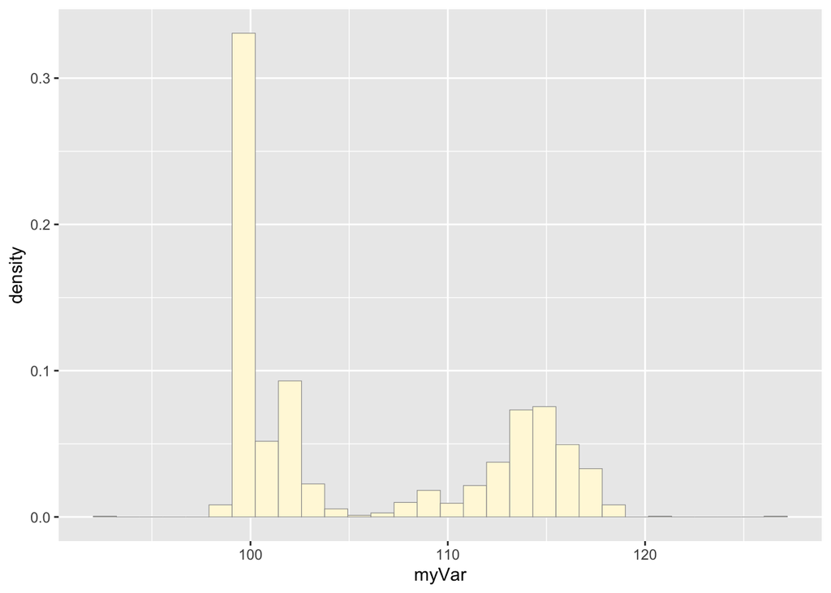

```r
p1 <- ggplot(data=z, aes(x=myVar, y=..density..)) +
  geom_histogram(color="grey60",fill="cornsilk",size=0.2)
print(p1) # plot a histogram of the data
```

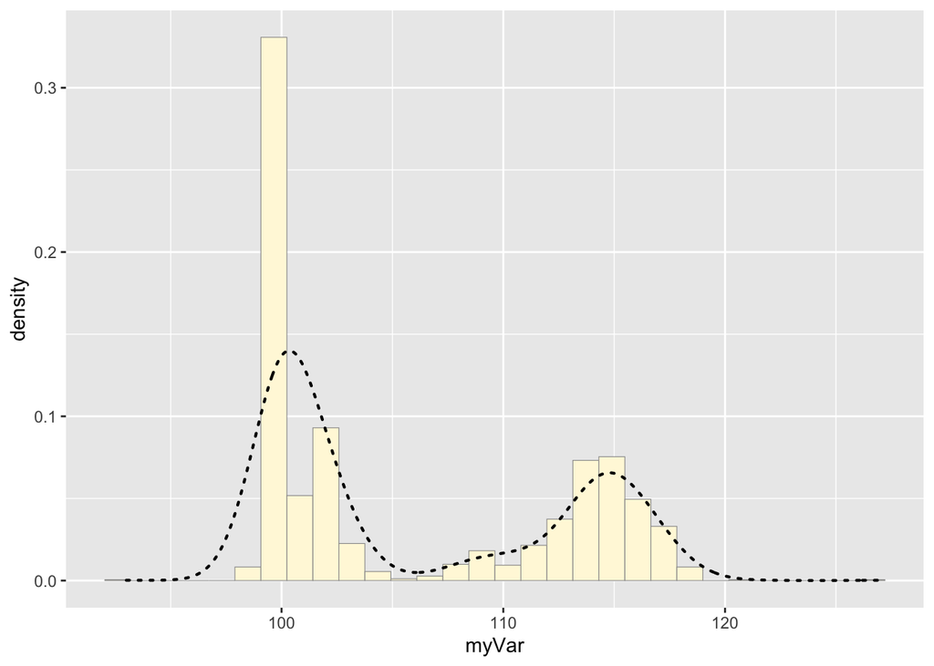

```r
p1 <-  p1 +  geom_density(linetype="dotted",size=0.75)
print(p1) #  add empirical density curve; black dotted line
```

```r
normPars <- fitdistr(z$myVar,"normal")
print(normPars)
```

```
##       mean           sd
##   105.9516129     6.8019623
##  (  0.1727700) (  0.1221668)
```

```r
str(normPars)
```

```
## List of 5
##  $ estimate: Named num [1:2] 106 6.8
##   ..- attr(*, "names")= chr [1:2] "mean" "sd"
##  $ sd      : Named num [1:2] 0.173 0.122
##   ..- attr(*, "names")= chr [1:2] "mean" "sd"
##  $ vcov    : num [1:2, 1:2] 0.0298 0 0 0.0149
##   ..- attr(*, "dimnames")=List of 2
##   .. ..$ : chr [1:2] "mean" "sd"
##   .. ..$ : chr [1:2] "mean" "sd"
##  $ n       : int 1550
##  $ loglik  : num -5171
##  - attr(*, "class")= chr "fitdistr"
```

```r
normPars$estimate["mean"] # get maximum likelihood parameters for normal density
```

```
##     mean
## 105.9516
```

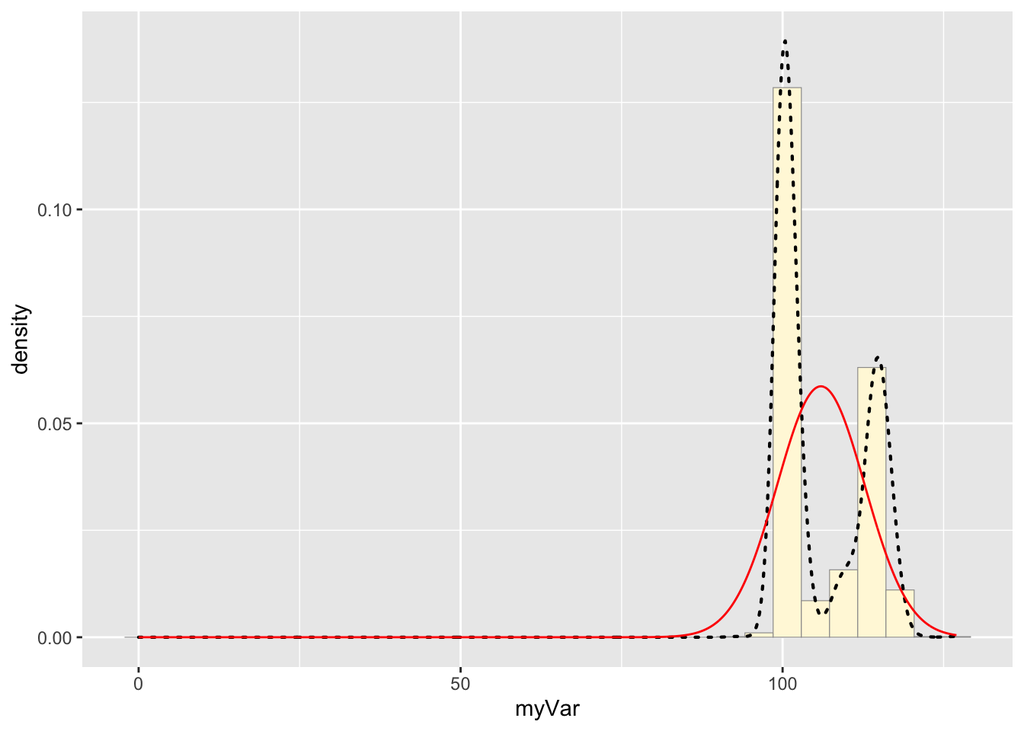

```r
meanML <- normPars$estimate["mean"]
sdML <- normPars$estimate["sd"]

xval <- seq(0,max(z$myVar),len=length(z$myVar))

 stat <- stat_function(aes(x = xval, y = ..y..), fun = dnorm, colour="red", n = length(z$myVar), args = list(mean = meanML, sd = sdML))
 p1 + stat # plot normal probability density; red line
```

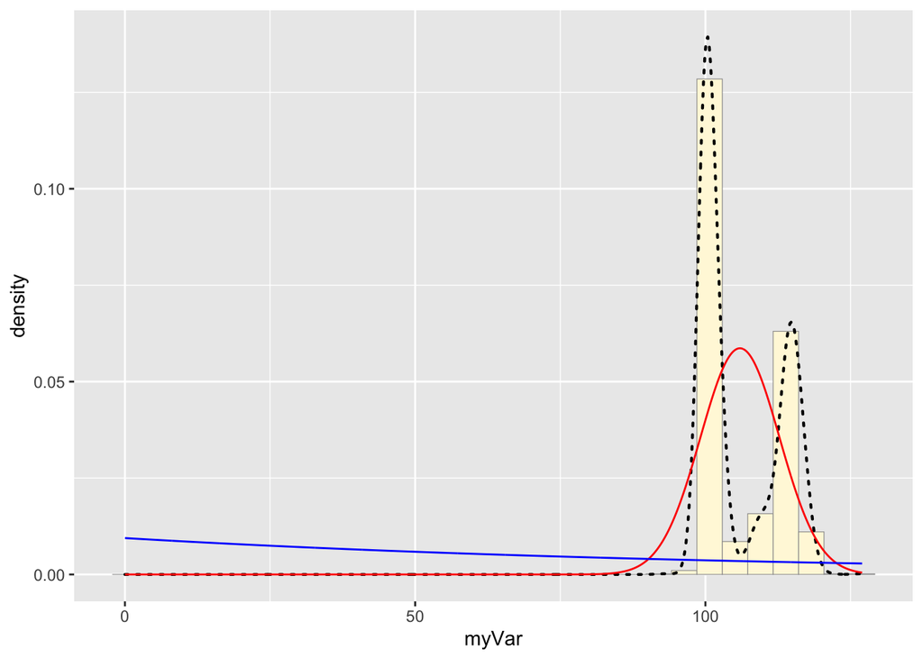

```r
 expoPars <- fitdistr(z$myVar,"exponential")
rateML <- expoPars$estimate["rate"]

stat2 <- stat_function(aes(x = xval, y = ..y..), fun = dexp, colour="blue", n = length(z$myVar), args = list(rate=rateML))
 p1 + stat + stat2 # plot exponential probability density; blue line
```

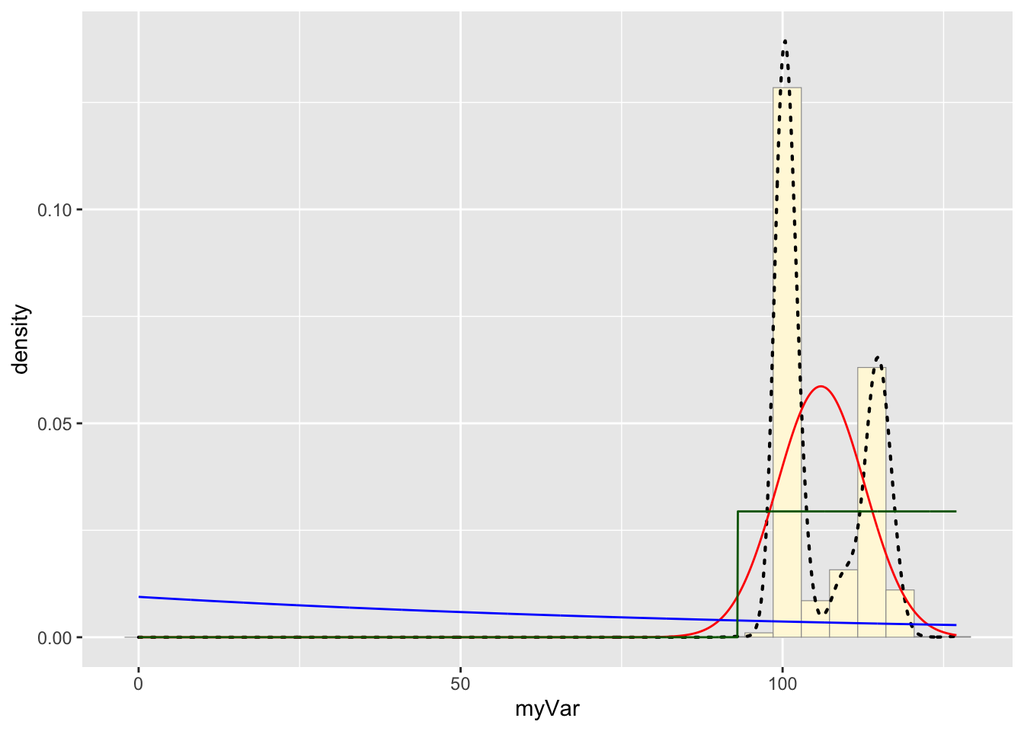

```r
 stat3 <- stat_function(aes(x = xval, y = ..y..), fun = dunif, colour="darkgreen", n = length(z$myVar), args = list(min=min(z$myVar), max=max(z$myVar)))
 p1 + stat + stat2 + stat3 # plot uniform probability density; green line
```

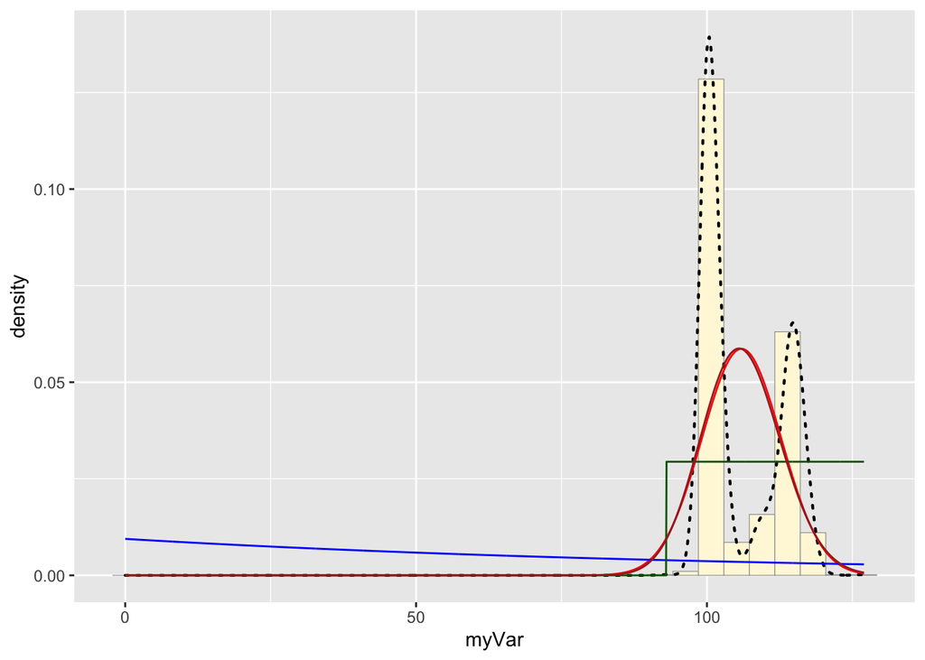

```r
 gammaPars <- fitdistr(z$myVar,"gamma")
shapeML <- gammaPars$estimate["shape"]
rateML <- gammaPars$estimate["rate"]

stat4 <- stat_function(aes(x = xval, y = ..y..), fun = dgamma, colour="brown", n = length(z$myVar), args = list(shape=shapeML, rate=rateML))
 p1 + stat + stat2 + stat3 + stat4 # plot gamma probability density; brown line
```

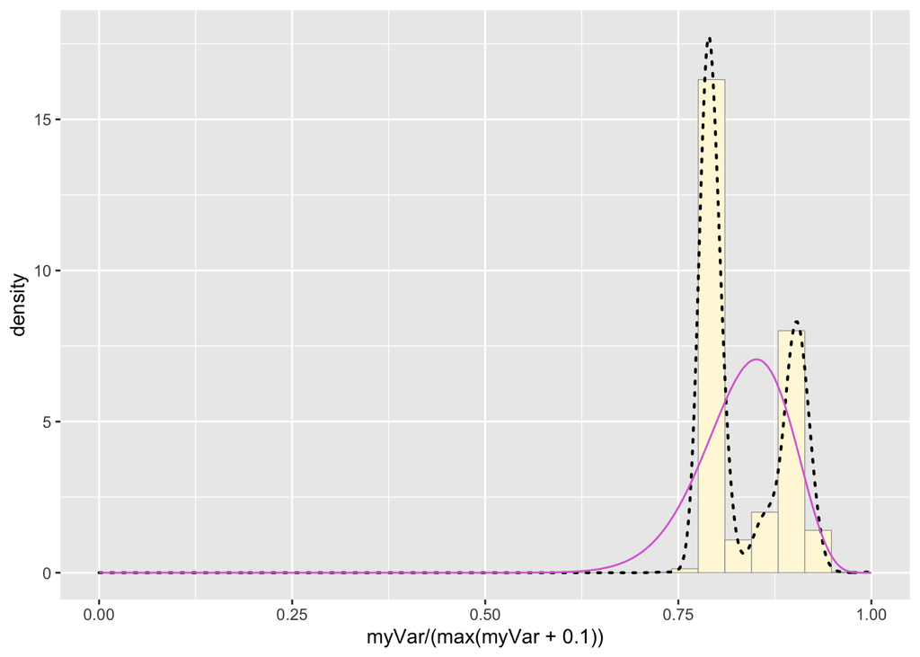

```r
pSpecial <- ggplot(data=z, aes(x=myVar/(max(myVar + 0.1)), y=..density..)) +
  geom_histogram(color="grey60",fill="cornsilk",size=0.2) +
  xlim(c(0,1)) +
  geom_density(size=0.75,linetype="dotted")

betaPars <- fitdistr(x=z$myVar/max(z$myVar + 0.1),start=list(shape1=1,shape2=2),"beta")
shape1ML <- betaPars$estimate["shape1"]
shape2ML <- betaPars$estimate["shape2"]

statSpecial <- stat_function(aes(x = xval, y = ..y..), fun = dbeta, colour="orchid", n = length(z$myVar), args = list(shape1=shape1ML,shape2=shape2ML))
pSpecial + statSpecial # plot beta probability density
```

```r
z <- read.table("../Bio381/MyDataFile2.csv",header=TRUE,sep=",")
names(z) <- list("ID","pop", "myVar")
z <- z[z$myVar>0,]
str(z)
```

```
## 'data.frame':    1550 obs. of  3 variables:
##  $ ID   : chr  "ALB-M011A01" "ALB-M011A02" "ALB-M011A03" "ALB-M011A04" ...
##  $ pop  : chr  "ALB" "ALB" "ALB" "ALB" ...
##  $ myVar: int  113 114 116 117 100 127 115 115 115 100 ...
```

```r
summary(z$myVar)
```

```
##    Min. 1st Qu.  Median    Mean 3rd Qu.    Max.
##    93.0   114.0   116.0   114.2   117.0   135.0
```

```r
str(z)
```

```
## 'data.frame':    1550 obs. of  3 variables:
##  $ ID   : chr  "ALB-M011A01" "ALB-M011A02" "ALB-M011A03" "ALB-M011A04" ...
##  $ pop  : chr  "ALB" "ALB" "ALB" "ALB" ...
##  $ myVar: int  113 114 116 117 100 127 115 115 115 100 ...
```

```r
summary(z)
```

```
##       ID                pop                myVar
##  Length:1550        Length:1550        Min.   : 93.0
##  Class :character   Class :character   1st Qu.:114.0
##  Mode  :character   Mode  :character   Median :116.0
##                                        Mean   :114.2
##                                        3rd Qu.:117.0
##                                        Max.   :135.0
```

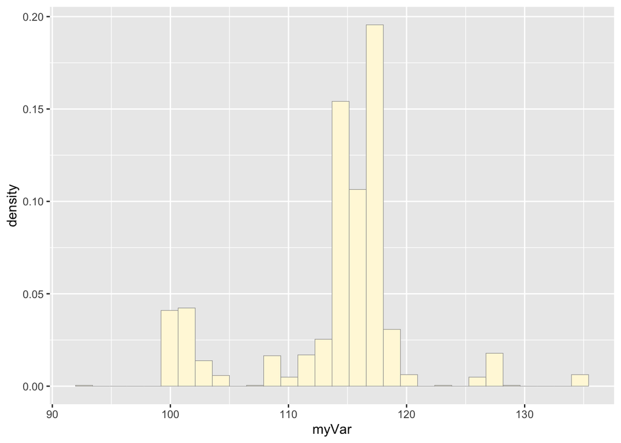

```r
p1 <- ggplot(data=z, aes(x=myVar, y=..density..)) +
  geom_histogram(color="grey60",fill="cornsilk",size=0.2)
print(p1) # plot a histogram of the data
```

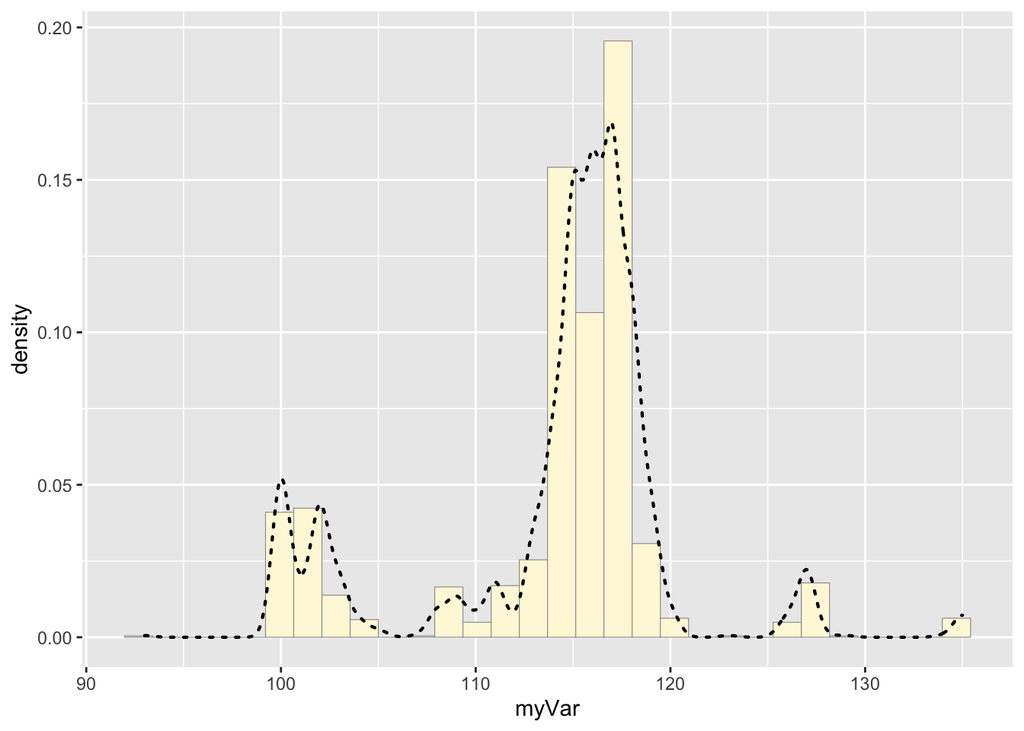

```r
p1 <-  p1 +  geom_density(linetype="dotted",size=0.75)
print(p1) #  add empirical density curve; black dotted line
```

```r
normPars <- fitdistr(z$myVar,"normal")
print(normPars)
```

```
##       mean           sd
##   114.1658065     6.3604822
##  (  0.1615564) (  0.1142376)
```

```r
str(normPars)
```

```
## List of 5
##  $ estimate: Named num [1:2] 114.17 6.36
##   ..- attr(*, "names")= chr [1:2] "mean" "sd"
##  $ sd      : Named num [1:2] 0.162 0.114
##   ..- attr(*, "names")= chr [1:2] "mean" "sd"
##  $ vcov    : num [1:2, 1:2] 0.0261 0 0 0.0131
##   ..- attr(*, "dimnames")=List of 2
##   .. ..$ : chr [1:2] "mean" "sd"
##   .. ..$ : chr [1:2] "mean" "sd"
##  $ n       : int 1550
##  $ loglik  : num -5067
##  - attr(*, "class")= chr "fitdistr"
```

```r
normPars$estimate["mean"] # get maximum likelihood parameters for normal density
```

```
##     mean
## 114.1658
```

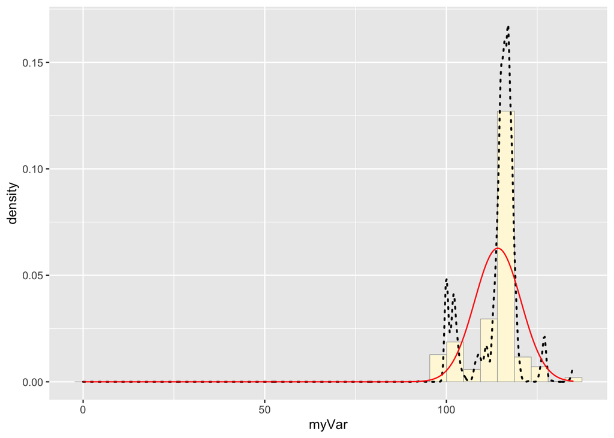

```r
meanML <- normPars$estimate["mean"]
sdML <- normPars$estimate["sd"]

xval <- seq(0,max(z$myVar),len=length(z$myVar))

 stat <- stat_function(aes(x = xval, y = ..y..), fun = dnorm, colour="red", n = length(z$myVar), args = list(mean = meanML, sd = sdML))
 p1 + stat # plot normal probability density; red line
```

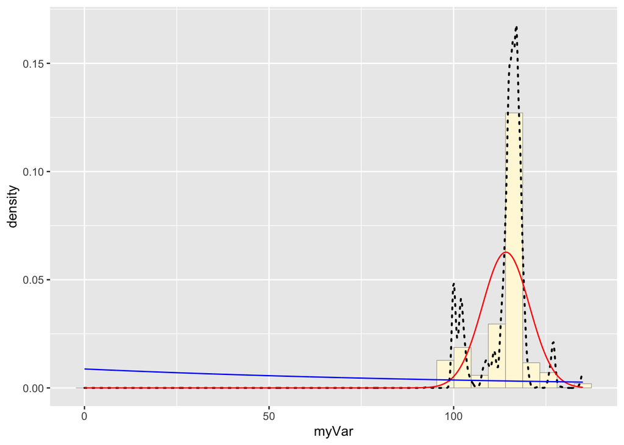

```r
 expoPars <- fitdistr(z$myVar,"exponential")
rateML <- expoPars$estimate["rate"]

stat2 <- stat_function(aes(x = xval, y = ..y..), fun = dexp, colour="blue", n = length(z$myVar), args = list(rate=rateML))
 p1 + stat + stat2 # plot exponential probability density; blue line
```

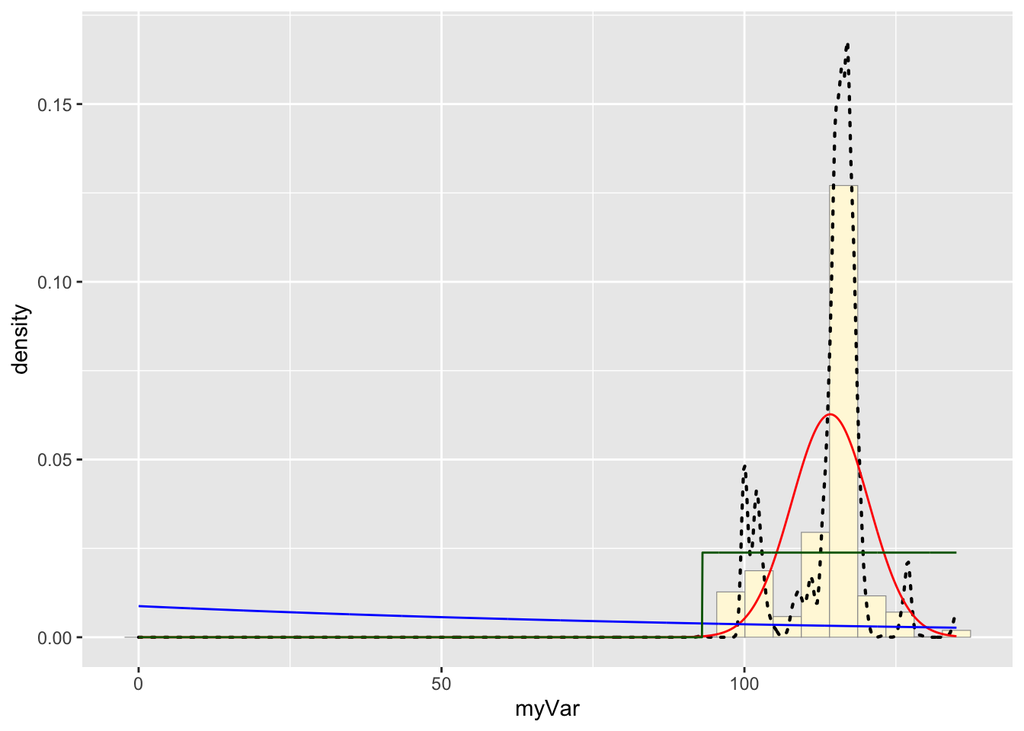

```r
stat3 <- stat_function(aes(x = xval, y = ..y..), fun = dunif, colour="darkgreen", n = length(z$myVar), args = list(min=min(z$myVar), max=max(z$myVar)))
p1 + stat + stat2 + stat3 # plot uniform probability density; green line
```

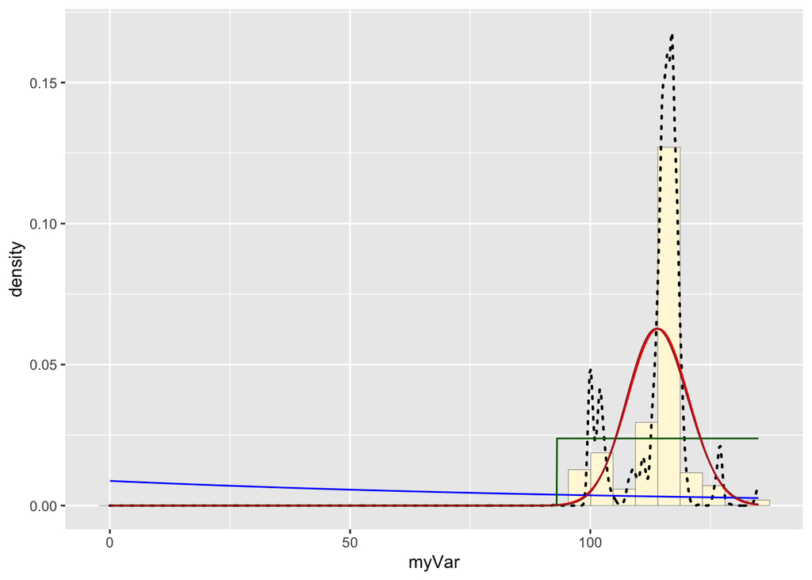

```r
gammaPars <- fitdistr(z$myVar,"gamma")
shapeML <- gammaPars$estimate["shape"]
rateML <- gammaPars$estimate["rate"]

stat4 <- stat_function(aes(x = xval, y = ..y..), fun = dgamma, colour="brown", n = length(z$myVar), args = list(shape=shapeML, rate=rateML))
 p1 + stat + stat2 + stat3 + stat4 # plot gamma probability density; brown line
```

The second column of data was less bimodal, and fit either a normal or gamma curve - the two curves were again nearly identical.

4. Simulating a new data set using the maximum likelihood parameters from the above gamma distribution, and comparing histograms

Maximum likelihood estimators of the parameters:

```r
data <- read.table("../Bio381/MyDataFile2.csv",header=TRUE,sep=",")
names(data) <- list("ID","pop", "myVar")
data <- z[z$myVar>0,]
print(data$myVar)
```

[output not shown]

[output cut: 72 more lines]

```r
data <- fitdistr(data$myVar, "gamma")
print(data)
```

```
##      shape         rate
##   321.967275     2.820173
##  ( 11.556479) (  0.101304)
```

```r
 #     shape         rate
 #  321.967275     2.820173
 # ( 11.556479) (  0.101304)
```

Next, use those ML parameters and length of my imported dataset to simulate new data:

```r
sim_data <- rgamma(n=1550, shape=data$estimate["shape"], rate=data$estimate["rate"])
summary(sim_data)
```

```
##    Min. 1st Qu.  Median    Mean 3rd Qu.    Max.
##   93.94  109.59  113.96  114.15  118.29  134.62
```

Finally, compare the resulting histograms & probability curves for the respective data sets.

```r
#Simulated data:

data <- read.table("../Bio381/MyDataFile2.csv",header=TRUE,sep=",")
names(data) <- list("ID","pop", "myVar")
data <- z[z$myVar>0,]
print(data$myVar)
```

[output not shown]

[output cut: 72 more lines]

```r
gammaPars <- fitdistr(data$myVar, "gamma")
#     shape         rate
#  321.967275     2.820173
# ( 11.556479) (  0.101304)

shapeML <- gammaPars$estimate["shape"]
rateML <- gammaPars$estimate["rate"]

sim_data <- data.frame(myVar=rgamma(n=1550, shape=shapeML, rate=rateML))
print(sim_data)
```

[output not shown]

[output cut: 1536 more lines]

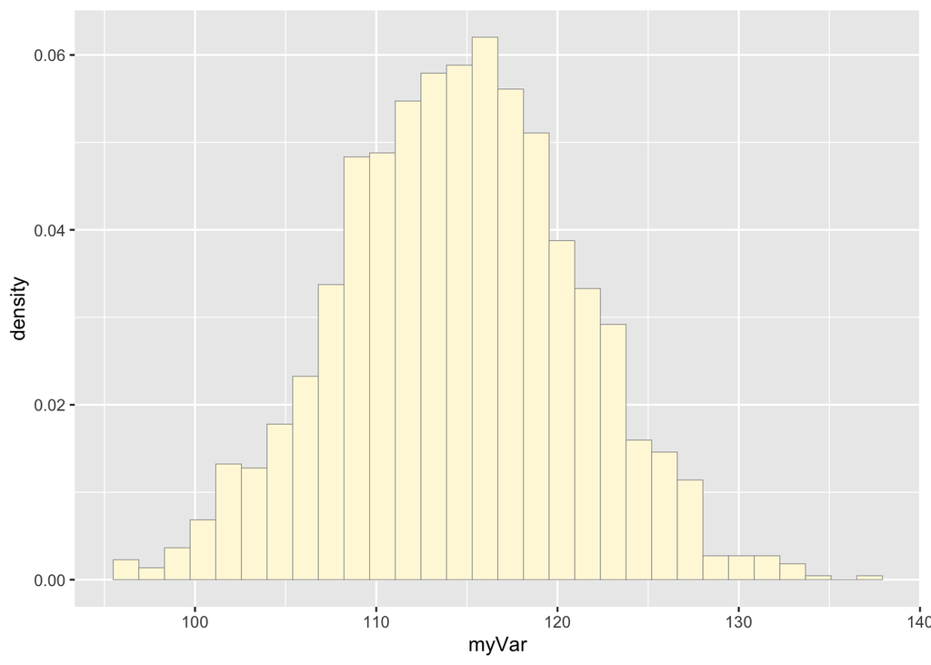

```r
sim_plot <- ggplot(data=sim_data, aes(x=myVar, y=..density..)) +
  geom_histogram(color="grey60",fill="cornsilk",size=0.2)
print(sim_plot) # plot a histogram of the data
```

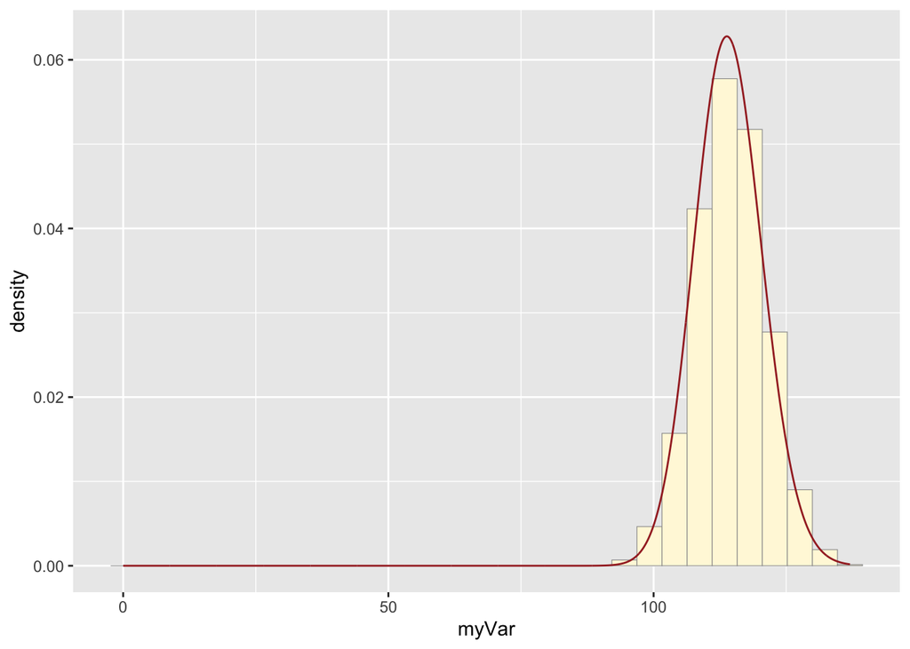

```r
sim_curve <- stat_function(aes(x = xval, y = ..y..), fun = dgamma, colour="brown", n = length(sim_data$myVar), args = list(shape=shapeML, rate=rateML))
sim_plot + stat4 # plot gamma probability density; brown line
```

```r
#Imported data stuff:

z <- read.table("../Bio381/MyDataFile2.csv",header=TRUE,sep=",")
names(z) <- list("ID","pop", "myVar")
z <- z[z$myVar>0,]
str(z)
```

```
## 'data.frame':    1550 obs. of  3 variables:
##  $ ID   : chr  "ALB-M011A01" "ALB-M011A02" "ALB-M011A03" "ALB-M011A04" ...
##  $ pop  : chr  "ALB" "ALB" "ALB" "ALB" ...
##  $ myVar: int  113 114 116 117 100 127 115 115 115 100 ...
```

```r
summary(z$myVar)
```

```
##    Min. 1st Qu.  Median    Mean 3rd Qu.    Max.
##    93.0   114.0   116.0   114.2   117.0   135.0
```

```r
str(z)
```

```
## 'data.frame':    1550 obs. of  3 variables:
##  $ ID   : chr  "ALB-M011A01" "ALB-M011A02" "ALB-M011A03" "ALB-M011A04" ...
##  $ pop  : chr  "ALB" "ALB" "ALB" "ALB" ...
##  $ myVar: int  113 114 116 117 100 127 115 115 115 100 ...
```

```r
summary(z)
```

```
##       ID                pop                myVar
##  Length:1550        Length:1550        Min.   : 93.0
##  Class :character   Class :character   1st Qu.:114.0
##  Mode  :character   Mode  :character   Median :116.0
##                                        Mean   :114.2
##                                        3rd Qu.:117.0
##                                        Max.   :135.0
```

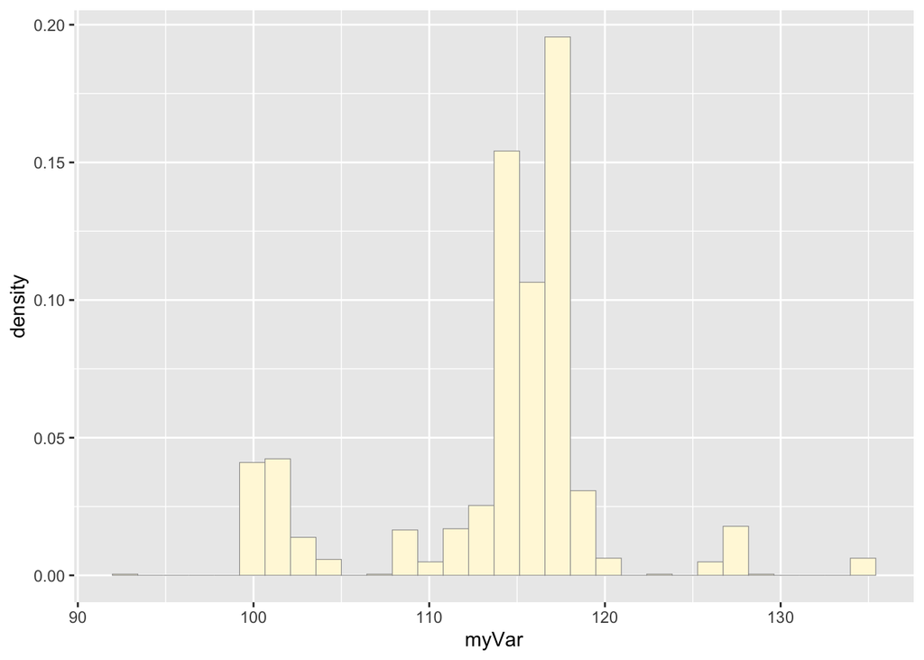

```r
p1 <- ggplot(data=z, aes(x=myVar, y=..density..)) +
  geom_histogram(color="grey60",fill="cornsilk",size=0.2)
print(p1) # plot a histogram of the data
```

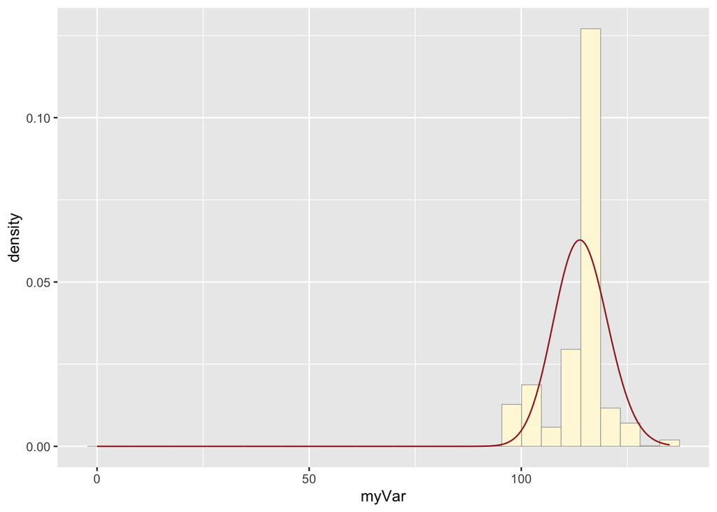

```r
gammaPars <- fitdistr(z$myVar,"gamma")
shapeML <- gammaPars$estimate["shape"]
rateML <- gammaPars$estimate["rate"]

stat4 <- stat_function(aes(x = xval, y = ..y..), fun = dgamma, colour="brown", n = length(z$myVar), args = list(shape=shapeML, rate=rateML))
p1 + stat4 # plot gamma probability density; brown line
```

The curve seems to match the simulated data better than my imported data. This means that the gamma distribution may not be the best probability distribution to describe the imported data. It’s not as obviously bimodal as the first data set I went through in question 3, but there is a slight peak before the large peak which skews the curve a bit. Therefore, the model does not do a great job of simulating realistic data, but the curve patterns are at least a little bit lined up with what we may expect to see.